# Regression

July 19 - August 2, 2025

Author

Adapted from Rafael Irizarry & Michael Love  
by Helena L. Crowell & Wolfgang Huber

# Colinearity and confounding

We use a “classical” data science / ML data set, the Boston housing data, a dataframe with 506 rows and 14 columns.

```r
library("MASS")
data("Boston")
head(Boston)
```

```
     crim zn indus chas   nox    rm  age    dis rad tax ptratio  black lstat medv
1 0.00632 18  2.31    0 0.538 6.575 65.2 4.0900   1 296    15.3 396.90  4.98 24.0
2 0.02731  0  7.07    0 0.469 6.421 78.9 4.9671   2 242    17.8 396.90  9.14 21.6
3 0.02729  0  7.07    0 0.469 7.185 61.1 4.9671   2 242    17.8 392.83  4.03 34.7
4 0.03237  0  2.18    0 0.458 6.998 45.8 6.0622   3 222    18.7 394.63  2.94 33.4
5 0.06905  0  2.18    0 0.458 7.147 54.2 6.0622   3 222    18.7 396.90  5.33 36.2
6 0.02985  0  2.18    0 0.458 6.430 58.7 6.0622   3 222    18.7 394.12  5.21 28.7
```

| varname | meaning |
| --- | --- |
| zn | proportion of residential land zoned for lots over 25,000 sq.ft |
| indus | proportion of non-retail business acres per town |
| chas | Charles River proximity (1 if tract bounds river; 0 otherwise) |
| nox | nitrogen oxides concentration (parts per 10 million) |
| rm | average number of rooms per dwelling |
| age | proportion of owner-occupied units built prior to 1940 |
| dis | weighted mean of distances to five Boston employment centres |
| rad | index of accessibility to radial highways |
| tax | full-value property-tax rate per $10,000 |
| ptratio | pupil-teacher ratio by town |
| black | $1000(b−0.63)^2$, where $b$ is the proportion of blacks |
| lstat | lower status of the population (percent) |
| medv | median value of owner-occupied homes in $1000s |

We do two linear regressions with $y$ the house value, and two predictors (`dis` and `rm`), or three (in addition, `nox`).

```r
fit1 = lm(medv ~ dis + rm, data = Boston)
coef(fit1)
```

```
(Intercept)         dis          rm
-34.6360502   0.4888485   8.8014118
```

```r
fit2 = lm(medv ~ dis + rm + nox, data = Boston)
coef(fit2)
```

```
(Intercept)         dis          rm         nox
-10.1181462  -0.6627196   8.0971906 -28.3432861
```

What is going on? The sign of the coefficient for `dis` has flipped. Does distance from where people work increase or decrease the house price? Let’s dig into the correlations between the variables.

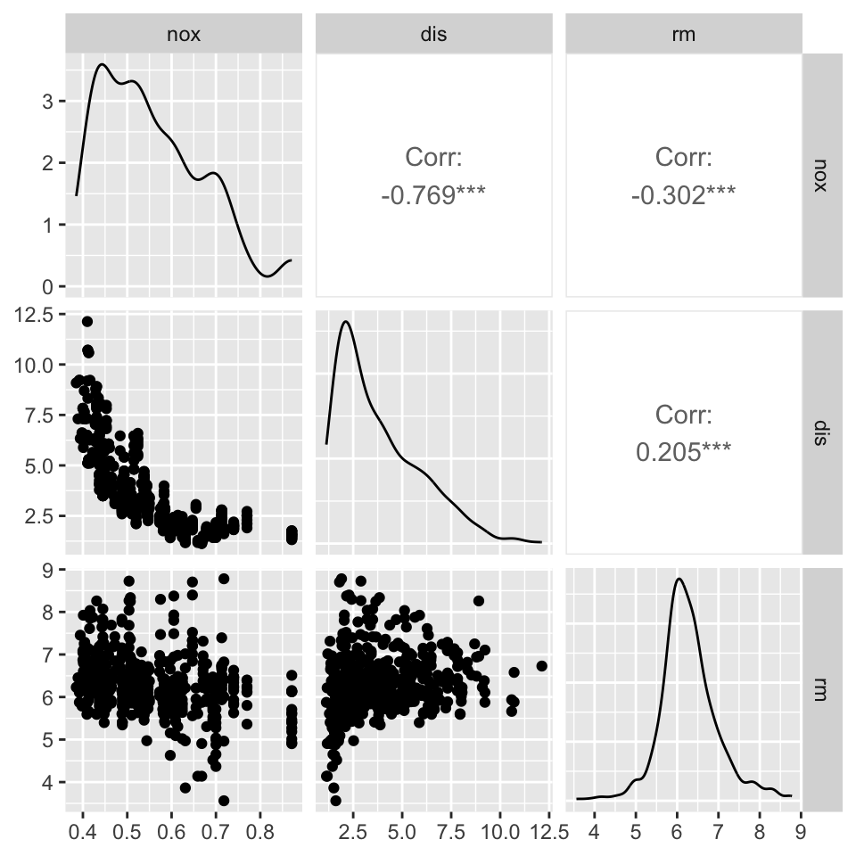

```r
library("GGally")
ggpairs(dplyr::select(Boston, nox, dis, rm))
```

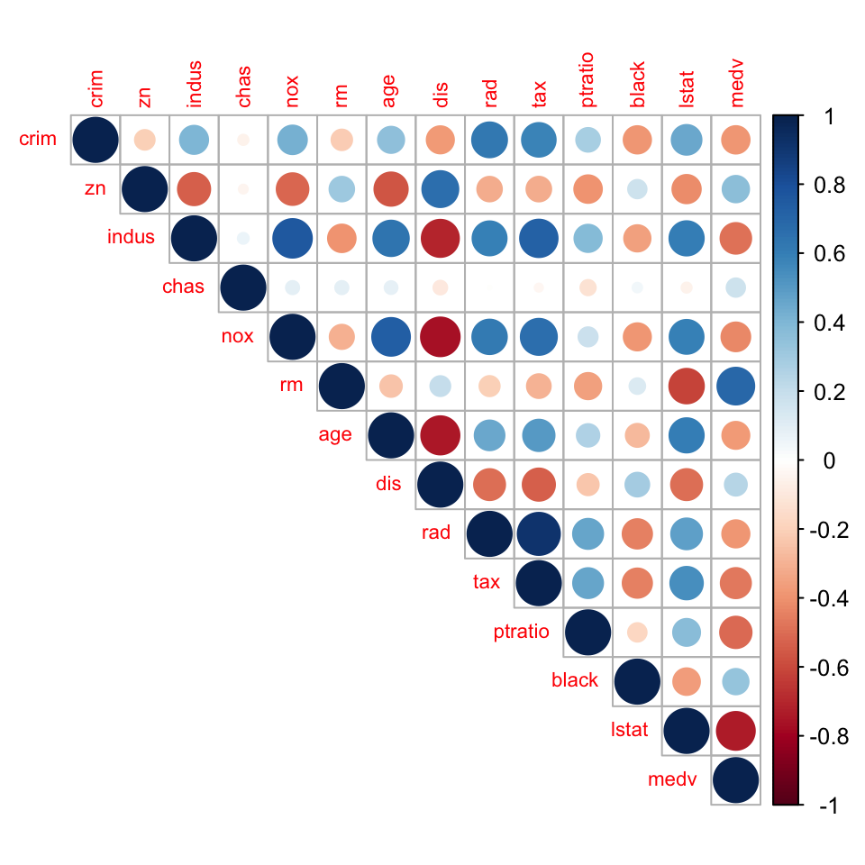

```r
library("corrplot")
corrplot(cor(Boston), method = "circle", type = "upper", tl.cex = 0.7)
```

# Blocking and pairing

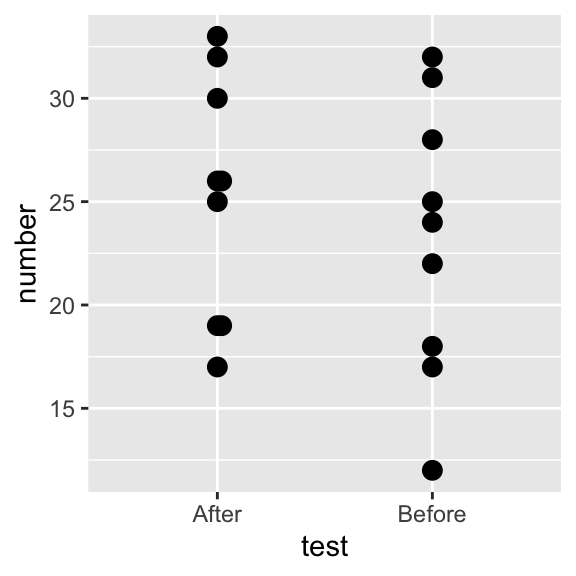

```r
library("ggbeeswarm")
library("BSDA")
data("Fitness")
ggplot(Fitness, aes(x = test, y = number)) + geom_beeswarm(size = 3)
```

```r
t.test(number ~ test, data = Fitness)
```

```
    Welch Two Sample t-test

data:  number by test
t = 0.67446, df = 15.736, p-value = 0.5098
alternative hypothesis: true difference in means between group After and group Before is not equal to 0
95 percent confidence interval:
 -4.29481  8.29481
sample estimates:
 mean in group After mean in group Before
            25.22222             23.22222
```

The p value for this test is not “significant”.

```r
fit = lm(number ~ test + subject, data = Fitness)
summary(fit)
```

```
Call:
lm(formula = number ~ test + subject, data = Fitness)

Residuals:
   Min     1Q Median     3Q    Max
-2.000 -0.875  0.000  0.875  2.000

Coefficients:
            Estimate Std. Error t value Pr(>|t|)
(Intercept)  31.0000     1.1487  26.988 3.83e-09 ***
testBefore   -2.0000     0.7265  -2.753  0.02494 *
subject2      2.0000     1.5411   1.298  0.23053
subject3    -12.0000     1.5411  -7.787 5.30e-05 ***
subject4     -6.0000     1.5411  -3.893  0.00459 **
subject5    -15.5000     1.5411 -10.058 8.13e-06 ***
subject6      1.0000     1.5411   0.649  0.53459
subject7     -5.0000     1.5411  -3.244  0.01180 *
subject8    -11.5000     1.5411  -7.462 7.18e-05 ***
subject9     -5.0000     1.5411  -3.244  0.01180 *
---
Signif. codes:  0 '***' 0.001 '**' 0.01 '*' 0.05 '.' 0.1 ' ' 1

Residual standard error: 1.541 on 8 degrees of freedom
Multiple R-squared:  0.9708,    Adjusted R-squared:  0.938
F-statistic: 29.57 on 9 and 8 DF,  p-value: 3.356e-05
```

The p value for `testBefore` (=difference before - after) is “significant”.

```r
FitnessW = tidyr::spread(Fitness, test, number)
t.test(FitnessW$After, FitnessW$Before, paired = TRUE)
```

```
    Paired t-test

data:  FitnessW$After and FitnessW$Before
t = 2.753, df = 8, p-value = 0.02494
alternative hypothesis: true mean difference is not equal to 0
95 percent confidence interval:
 0.3247268 3.6752732
sample estimates:
mean difference
              2
```

The paired $t$-test is the same as the linear model with `subject` as a covariate.

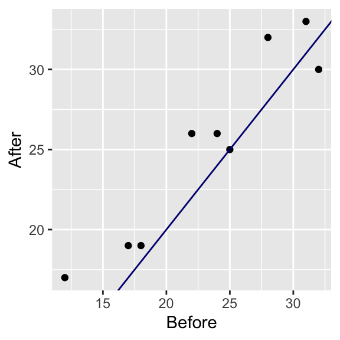

```r
ggplot(FitnessW, aes(x = Before, y = After)) + geom_point() + geom_abline(col = "#000080")
```

# Contrasts and interactions

We use a dataset that compares the friction coefficients on the different legs of a spider. Specifically, we will ask whether more friction comes from a pushing or pulling motion of the leg. The original paper from which the data originate:

Jonas O. Wolff & Stanislav N. Gorb, [Radial arrangement of Janus-like setae permits friction control in spiders](http://dx.doi.org/10.1038/srep01101), Scientific Reports, 22 January 2013.

The abstract of the paper says:

> The hunting spider Cupiennius salei (Arachnida, Ctenidae) possesses hairy attachment pads (claw tufts) at its distal legs, consisting of directional branched setae… Friction of claw tufts on smooth glass was measured to reveal the functional effect of seta arrangement within the pad.

We included the data in the GitHub repository. As a fallback, we can also download them from [here](https://raw.githubusercontent.com/genomicsclass/dagdata/master/inst/extdata/spider_wolff_gorb_2013.csv).

```r
url <- "https://raw.githubusercontent.com/genomicsclass/dagdata/master/inst/extdata/spider_wolff_gorb_2013.csv"
csv <- "spider_wolff_gorb_2013.csv"
if (!file.exists(csv)) download.file(url, csv, quiet=TRUE)
spider <- read.csv(csv, skip = 1)
```

#### Initial visual inspection of the data

Each measurement comes from one of the leg pairs while a leg is either pushing or pulling. So we have two variables:

```r
table(spider$leg, spider$type)
```

```
     pull push
  L1   34   34
  L2   15   15
  L3   52   52
  L4   40   40
```

We can make a plot summarizing the measurements for each of the eight pairs:

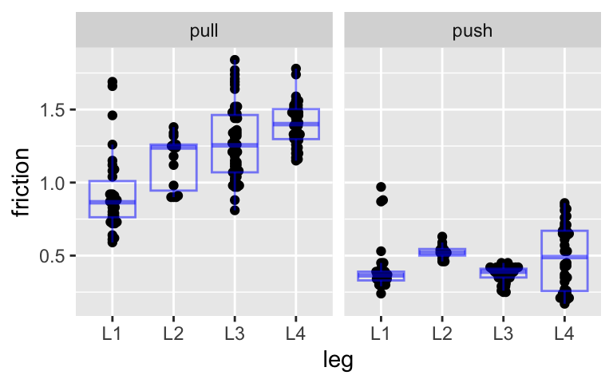

Comparison of friction coefficients of spiders’ different leg pairs. The friction coefficient is calculated as the ratio of two forces (see paper Methods), so it is unitless.

```r
library("ggbeeswarm")
ggplot(spider, aes(y = friction, x = leg)) + geom_beeswarm() +
  geom_boxplot(aes(fill = type), outliers = FALSE, col = "#0000ff80", fill = "#00000000") +
  facet_grid(col = vars(type))
```

What we can immediately see are two trends:

- The pulling motion has higher friction than the pushing motion.
- The leg pairs towards the back of the spider (L4 being the last) have higher pulling friction.

**Heteroskedasticity**

Another thing to notice is that the groups have different spread around their average, what we call *within-group variance*. This phenomenon, also called *heteroskedasticity*, can be a problem for the kinds of linear models we explore below, since we will be assuming that around the group means, the data are distributed identically, meaning the same variance within each group. The consequence of ignoring the different variances for the different groups is that comparisons between those groups with small variances will be overly “conservative” (because the overall estimate of variance is too large), and comparisons between groups with large variances will be overly confident (because the estimate is too small).

Sometimes it is possible to transform your way out of this: if the spread increases with the mean, such that groups with mean values also have larger spread, a possibility is to transform the data with a function such as the `log` or `sqrt`. This looks like it could be useful here, since three of the four push groups (L1, L2, L3) have the smallest friction values and also the smallest spread.

Some alternative tests for comparing groups without transforming the values first include: t-tests without the equal variance assumption using a “Welch” or “Satterthwaite approximation”, or the Wilcoxon rank sum test mentioned previously. However here, for simplicity of illustration, we will fit a model that assumes equal variance and shows the different kinds of linear model designs using this dataset, setting aside the issue of different within-group variances.

#### A linear model with one variable

To remind ourselves how the simple two-group linear model looks, we will subset the data to include only the L1 leg pair, and run `lm`:

```r
spider.sub <- dplyr::filter(spider, leg == "L1")
fit <- lm(friction ~ type, data = spider.sub)
summary(fit)
```

```
Call:
lm(formula = friction ~ type, data = spider.sub)

Residuals:
     Min       1Q   Median       3Q      Max
-0.33147 -0.10735 -0.04941 -0.00147  0.76853

Coefficients:
            Estimate Std. Error t value Pr(>|t|)
(Intercept)  0.92147    0.03827  24.078  < 2e-16 ***
typepush    -0.51412    0.05412  -9.499  5.7e-14 ***
---
Signif. codes:  0 '***' 0.001 '**' 0.01 '*' 0.05 '.' 0.1 ' ' 1

Residual standard error: 0.2232 on 66 degrees of freedom
Multiple R-squared:  0.5776,    Adjusted R-squared:  0.5711
F-statistic: 90.23 on 1 and 66 DF,  p-value: 5.698e-14
```

```r
(coefs <- coef(fit))
```

```
(Intercept)    typepush
  0.9214706  -0.5141176
```

These two estimated coefficients are the mean of the pull observations (the first estimated coefficient) and the difference between the means of the two groups (the second coefficient).

**Question**

Using the subset that includes only data on the L1 leg pair (`spider.sub`),

1. Compute the average friction of “pull” type legs.
2. Compute the difference in average friction between “push” and “pull” type legs.

#### Examining the estimated coefficients

Now we show the coefficient estimates from the linear model in a diagram with arrows (code not shown).

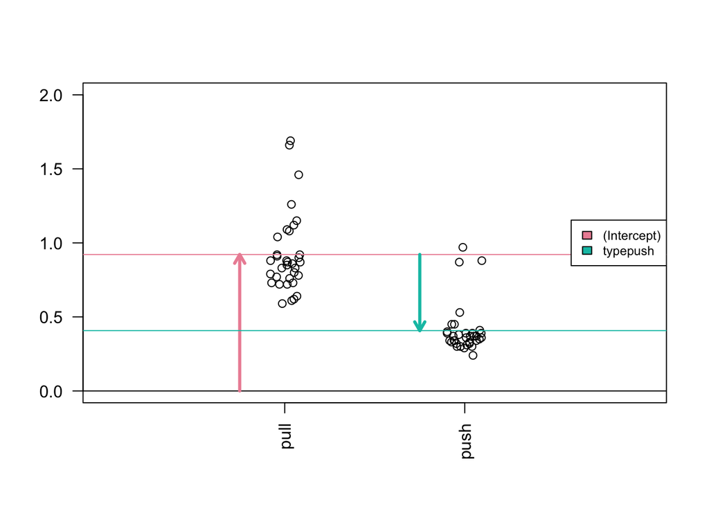

#### A linear model with two variables

To estimate coefficients for this model, we use `lm` with the formula `~ type + leg`. We’ll save the linear model to `fitTL` standing for a *fit* with *Type* and *Leg*.

```r
fitTL <- lm(friction ~ type + leg, data=spider)
summary(fitTL)
```

```
Call:
lm(formula = friction ~ type + leg, data = spider)

Residuals:
     Min       1Q   Median       3Q      Max
-0.46392 -0.13441 -0.00525  0.10547  0.69509

Coefficients:
            Estimate Std. Error t value Pr(>|t|)
(Intercept)  1.05392    0.02816  37.426  < 2e-16 ***
typepush    -0.77901    0.02482 -31.380  < 2e-16 ***
legL2        0.17192    0.04569   3.763 0.000205 ***
legL3        0.16049    0.03251   4.937 1.37e-06 ***
legL4        0.28134    0.03438   8.183 1.01e-14 ***
---
Signif. codes:  0 '***' 0.001 '**' 0.01 '*' 0.05 '.' 0.1 ' ' 1

Residual standard error: 0.2084 on 277 degrees of freedom
Multiple R-squared:  0.7916,    Adjusted R-squared:  0.7886
F-statistic:   263 on 4 and 277 DF,  p-value: < 2.2e-16
```

```r
(coefs <- coef(fitTL))
```

```
(Intercept)    typepush       legL2       legL3       legL4
  1.0539153  -0.7790071   0.1719216   0.1604921   0.2813382
```

R uses the name `coefficient` to denote the component containing the least squares **estimates**. It is important to remember that the coefficients are parameters that we do not observe, but only estimate.

#### Mathematical representation

The model we are fitting above can be written as

$$Y_i = \beta_0 + \beta_1 x_{i,1} + \beta_2 x_{i,2} + \beta_3 x_{i,3} + \beta_4 x_{i,4} + \varepsilon_i, i=1,\dots,N$$

#### Examining the estimated coefficients

We can make the same plot as before, with arrows for each of the estimated coefficients in the model (code not shown).

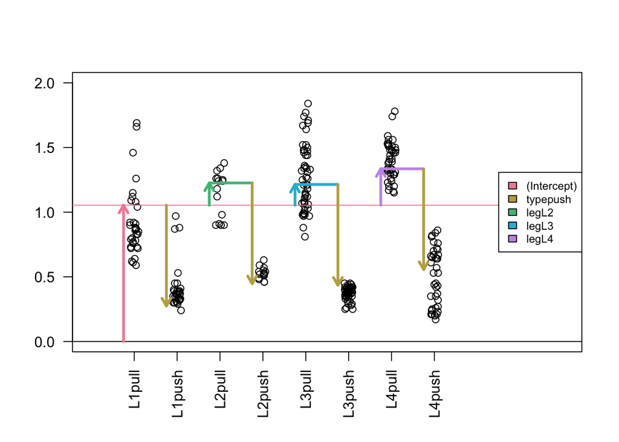

We are **assuming** that the effects are additive. However, as we demonstrate in more detail below, this particular dataset is better described with a model including interactions.

## Linear Model with Interactions

In the previous linear model, we assumed that the push vs. pull effect was the same for all of the leg pairs (the same orange arrow). You can easily see that this does not capture the trends in the data that well. That is, the tips of the arrows did not line up perfectly with the group averages. For the L1 leg pair, the push vs. pull estimated coefficient was too large, and for the L3 leg pair, the push vs. pull coefficient was somewhat too small.

*Interaction terms* will help us overcome this problem by introducing additional coefficients to compensate for differences in the push vs. pull effect across the 4 groups. As we already have a push vs. pull term in the model, we only need to add three more terms to have the freedom to find leg-pair-specific push vs. pull differences.

We can rebuild our linear model with an interaction between `type` and `leg`, by including an extra term in the formula `type:leg`. The `:` symbol adds an interaction between the two variables surrounding it. An equivalent way to specify this model is `~ type*leg`, which will expand to the formula `~ type + leg + type:leg`, with main effects for `type`, `leg` and an interaction term `type:leg`.

We can run the linear model using the same code as before:

```r
fitX <- lm(friction ~ type + leg + type:leg, data=spider)
summary(fitX)
```

```
Call:
lm(formula = friction ~ type + leg + type:leg, data = spider)

Residuals:
     Min       1Q   Median       3Q      Max
-0.46385 -0.10735 -0.01111  0.07848  0.76853

Coefficients:
               Estimate Std. Error t value Pr(>|t|)
(Intercept)     0.92147    0.03266  28.215  < 2e-16 ***
typepush       -0.51412    0.04619 -11.131  < 2e-16 ***
legL2           0.22386    0.05903   3.792 0.000184 ***
legL3           0.35238    0.04200   8.390 2.62e-15 ***
legL4           0.47928    0.04442  10.789  < 2e-16 ***
typepush:legL2 -0.10388    0.08348  -1.244 0.214409
typepush:legL3 -0.38377    0.05940  -6.461 4.73e-10 ***
typepush:legL4 -0.39588    0.06282  -6.302 1.17e-09 ***
---
Signif. codes:  0 '***' 0.001 '**' 0.01 '*' 0.05 '.' 0.1 ' ' 1

Residual standard error: 0.1904 on 274 degrees of freedom
Multiple R-squared:  0.8279,    Adjusted R-squared:  0.8235
F-statistic: 188.3 on 7 and 274 DF,  p-value: < 2.2e-16
```

```r
(coefs <- coef(fitX))
```

```
   (Intercept)       typepush          legL2          legL3          legL4 typepush:legL2 typepush:legL3 typepush:legL4
     0.9214706     -0.5141176      0.2238627      0.3523756      0.4792794     -0.1038824     -0.3837670     -0.3958824
```

#### Examining the estimated coefficients

Now, as we have eight terms in the model and eight parameters, you can check that the tips of the arrowheads are exactly equal to the group means (code not shown).

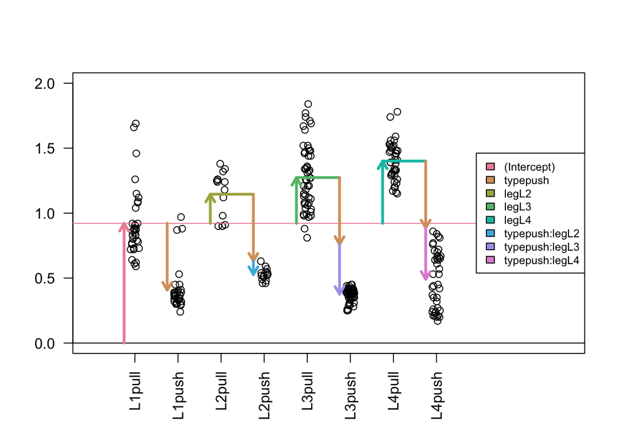

## Analysis of Variance

Suppose that we want to know if the push vs. pull difference is different across leg pairs in general. We do not want to compare any two leg pairs in particular, but rather we want to know if the three interaction terms which represent differences in the push vs. pull difference across leg pairs are larger than we would expect them to be if the push vs. pull difference was in fact equal across all leg pairs.

Such a question can be answered by an *analysis of variance*, which is often abbreviated as ANOVA. ANOVA compares the reduction in the sum of squares of the residuals for models of different complexity. The model with eight coefficients is more complex than the model with five coefficients where we assumed the push vs. pull difference was equal across leg pairs. The least complex model would only use a single coefficient, an intercept. Under certain assumptions we can also perform inference that determines the probability of improvements as large as what we observed. Let’s first print the result of an ANOVA in R and then examine the results in detail:

```r
anova(fitX)
```

```
Analysis of Variance Table

Response: friction
           Df Sum Sq Mean Sq  F value    Pr(>F)
type        1 42.783  42.783 1179.713 < 2.2e-16 ***
leg         3  2.921   0.974   26.847 2.972e-15 ***
type:leg    3  2.098   0.699   19.282 2.256e-11 ***
Residuals 274  9.937   0.036
---
Signif. codes:  0 '***' 0.001 '**' 0.01 '*' 0.05 '.' 0.1 ' ' 1
```

The first line tells us that adding a variable `type` (push or pull) to the design is very useful (reduces the sum of squared residuals) compared to a model with only an intercept. We can see that it is useful, because this single coefficient reduces the sum of squares by 42.783.